# Clusters and Classification

This is the Clustering and Classification homework. We’ll start by taking a gander at the data.

```r
library(MASS)
data("Boston")
str(Boston);View(Boston)
```

```
## 'data.frame':    506 obs. of  14 variables:
##  $ crim   : num  0.00632 0.02731 0.02729 0.03237 0.06905 ...
##  $ zn     : num  18 0 0 0 0 0 12.5 12.5 12.5 12.5 ...
##  $ indus  : num  2.31 7.07 7.07 2.18 2.18 2.18 7.87 7.87 7.87 7.87 ...
##  $ chas   : int  0 0 0 0 0 0 0 0 0 0 ...
##  $ nox    : num  0.538 0.469 0.469 0.458 0.458 0.458 0.524 0.524 0.524 0.524 ...
##  $ rm     : num  6.58 6.42 7.18 7 7.15 ...
##  $ age    : num  65.2 78.9 61.1 45.8 54.2 58.7 66.6 96.1 100 85.9 ...
##  $ dis    : num  4.09 4.97 4.97 6.06 6.06 ...
##  $ rad    : int  1 2 2 3 3 3 5 5 5 5 ...
##  $ tax    : num  296 242 242 222 222 222 311 311 311 311 ...
##  $ ptratio: num  15.3 17.8 17.8 18.7 18.7 18.7 15.2 15.2 15.2 15.2 ...
##  $ black  : num  397 397 393 395 397 ...
##  $ lstat  : num  4.98 9.14 4.03 2.94 5.33 ...
##  $ medv   : num  24 21.6 34.7 33.4 36.2 28.7 22.9 27.1 16.5 18.9 ...
```

These variable names tell us little about what they represent. I’ll just copypaste the descriptions from the original [website](https://stat.ethz.ch/R-manual/R-devel/library/MASS/html/Boston.html):

crim

```
per capita crime rate by town.
```

zn

```
proportion of residential land zoned for lots over 25,000 sq.ft.
```

indus

```
proportion of non-retail business acres per town.
```

chas

```
Charles River dummy variable (= 1 if tract bounds river; 0 otherwise).
```

nox

```
nitrogen oxides concentration (parts per 10 million).
```

rm

```
average number of rooms per dwelling.
```

age

```
proportion of owner-occupied units built prior to 1940.
```

dis

```
weighted mean of distances to five Boston employment centres.
```

rad

```
index of accessibility to radial highways.
```

tax

```
full-value property-tax rate per \$10,000.
```

ptratio

```
pupil-teacher ratio by town.
```

black

```
1000(Bk - 0.63)^2 where Bk is the proportion of blacks by town.
```

lstat

```
lower status of the population (percent).
```

medv

```
median value of owner-occupied homes in \$1000s.
```

Not even the host page tells us much about the purpose of this dataset. If I had to guess, I’d guess it was collected to analyze correlates and predictors of house prices. Here are the summaries:

```r
summary(Boston)
```

```
##       crim                zn             indus            chas
##  Min.   : 0.00632   Min.   :  0.00   Min.   : 0.46   Min.   :0.00000
##  1st Qu.: 0.08204   1st Qu.:  0.00   1st Qu.: 5.19   1st Qu.:0.00000
##  Median : 0.25651   Median :  0.00   Median : 9.69   Median :0.00000
##  Mean   : 3.61352   Mean   : 11.36   Mean   :11.14   Mean   :0.06917
##  3rd Qu.: 3.67708   3rd Qu.: 12.50   3rd Qu.:18.10   3rd Qu.:0.00000
##  Max.   :88.97620   Max.   :100.00   Max.   :27.74   Max.   :1.00000
##       nox               rm             age              dis
##  Min.   :0.3850   Min.   :3.561   Min.   :  2.90   Min.   : 1.130
##  1st Qu.:0.4490   1st Qu.:5.886   1st Qu.: 45.02   1st Qu.: 2.100
##  Median :0.5380   Median :6.208   Median : 77.50   Median : 3.207
##  Mean   :0.5547   Mean   :6.285   Mean   : 68.57   Mean   : 3.795
##  3rd Qu.:0.6240   3rd Qu.:6.623   3rd Qu.: 94.08   3rd Qu.: 5.188
##  Max.   :0.8710   Max.   :8.780   Max.   :100.00   Max.   :12.127
##       rad              tax           ptratio          black
##  Min.   : 1.000   Min.   :187.0   Min.   :12.60   Min.   :  0.32
##  1st Qu.: 4.000   1st Qu.:279.0   1st Qu.:17.40   1st Qu.:375.38
##  Median : 5.000   Median :330.0   Median :19.05   Median :391.44
##  Mean   : 9.549   Mean   :408.2   Mean   :18.46   Mean   :356.67
##  3rd Qu.:24.000   3rd Qu.:666.0   3rd Qu.:20.20   3rd Qu.:396.23
##  Max.   :24.000   Max.   :711.0   Max.   :22.00   Max.   :396.90
##      lstat            medv
##  Min.   : 1.73   Min.   : 5.00
##  1st Qu.: 6.95   1st Qu.:17.02
##  Median :11.36   Median :21.20
##  Mean   :12.65   Mean   :22.53
##  3rd Qu.:16.95   3rd Qu.:25.00
##  Max.   :37.97   Max.   :50.00
```

Because Linear Discriminant Analysis is linear, it requires the explanatory variables to be continuous. That is doubtless why this dataset was chosen for this chapter – there are only numeric variables. Despite the use of the word *linear*, LDA does NOT require the predictor variables to be linear. It only requires that they can be represented numerically. Even our Boston dataset contains one binary variable, namely *chas*. Since LDA apparently places no requirements on the nature of the predictor variables, it is quite a versatile statistical tool indeed. What it does require is that the predictors be normally distributed and have the same variance. However, according to [this page](http://machinelearningmastery.com/linear-discriminant-analysis-for-machine-learning/), there are valid work-arounds even when these requirements are not met.

We will now proceed to draw a plot of the correlations of each pair of variables:

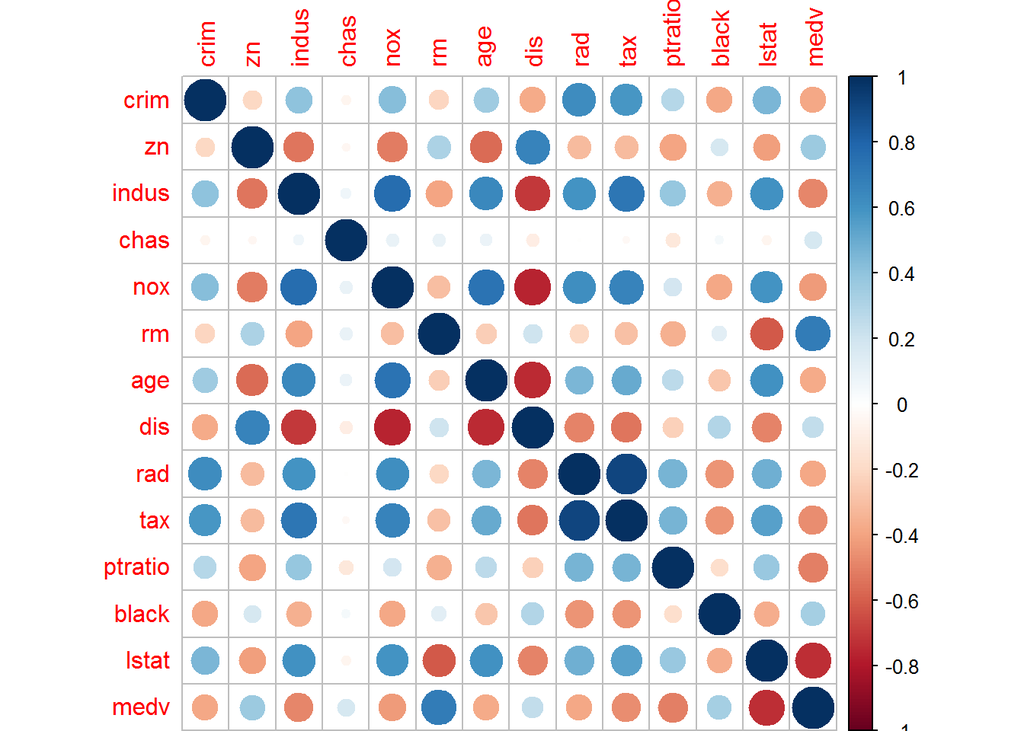

```r
library("corrplot");library("tidyverse")
(matriisi<-cor(Boston)) %>% corrplot(method="circle")
```

Circle diameter and darkness illustrate the strength of the variable’s correlation with the variable that intersects with it in the matrix. Blue color means a positive correlation, red is negative. The strongest correlations that catch my eye in this plot are:

- Air pollution levels and distance from large employment centers (negative). This is a ‘well, duh’ observation – of course pollution is lower the farther you get from the chimneys and smokestacks.
- Property tax and the amount of industry in town – this correlation is not at all self-evident to me. I would have assumed that taxes are lower in industrial centers because industrious people create wealth and don’t need income redistribution in the form of high taxes. But I seem to be missing something critical.
- Distance from emplyoment centers is also strongly negatively correlated with the amount of industry in town. I guess this means people don’t want to run their factories in remote locations where the long commute would turn off potential employees.

Now it’s time to scale the data.

```r
Boston.unscaled<-Boston #Backing up the unscaled version
Boston<-scale(Boston)
summary(Boston)
```

```
##       crim                 zn               indus
##  Min.   :-0.419367   Min.   :-0.48724   Min.   :-1.5563
##  1st Qu.:-0.410563   1st Qu.:-0.48724   1st Qu.:-0.8668
##  Median :-0.390280   Median :-0.48724   Median :-0.2109
##  Mean   : 0.000000   Mean   : 0.00000   Mean   : 0.0000
##  3rd Qu.: 0.007389   3rd Qu.: 0.04872   3rd Qu.: 1.0150
##  Max.   : 9.924110   Max.   : 3.80047   Max.   : 2.4202
##       chas              nox                rm               age
##  Min.   :-0.2723   Min.   :-1.4644   Min.   :-3.8764   Min.   :-2.3331
##  1st Qu.:-0.2723   1st Qu.:-0.9121   1st Qu.:-0.5681   1st Qu.:-0.8366
##  Median :-0.2723   Median :-0.1441   Median :-0.1084   Median : 0.3171
##  Mean   : 0.0000   Mean   : 0.0000   Mean   : 0.0000   Mean   : 0.0000
##  3rd Qu.:-0.2723   3rd Qu.: 0.5981   3rd Qu.: 0.4823   3rd Qu.: 0.9059
##  Max.   : 3.6648   Max.   : 2.7296   Max.   : 3.5515   Max.   : 1.1164
##       dis               rad               tax             ptratio
##  Min.   :-1.2658   Min.   :-0.9819   Min.   :-1.3127   Min.   :-2.7047
##  1st Qu.:-0.8049   1st Qu.:-0.6373   1st Qu.:-0.7668   1st Qu.:-0.4876
##  Median :-0.2790   Median :-0.5225   Median :-0.4642   Median : 0.2746
##  Mean   : 0.0000   Mean   : 0.0000   Mean   : 0.0000   Mean   : 0.0000
##  3rd Qu.: 0.6617   3rd Qu.: 1.6596   3rd Qu.: 1.5294   3rd Qu.: 0.8058
##  Max.   : 3.9566   Max.   : 1.6596   Max.   : 1.7964   Max.   : 1.6372
##      black             lstat              medv
##  Min.   :-3.9033   Min.   :-1.5296   Min.   :-1.9063
##  1st Qu.: 0.2049   1st Qu.:-0.7986   1st Qu.:-0.5989
##  Median : 0.3808   Median :-0.1811   Median :-0.1449
##  Mean   : 0.0000   Mean   : 0.0000   Mean   : 0.0000
##  3rd Qu.: 0.4332   3rd Qu.: 0.6024   3rd Qu.: 0.2683
##  Max.   : 0.4406   Max.   : 3.5453   Max.   : 2.9865
```

Now every variable has been standardized and centered by subtracting the mean from the value and dividing the remainder by the standard deviation of that variable. It makes comparisons of variance much easier and more intuitive. Next we convert *crim*(e rate) into a categorical variable AKA factor. This time we also do what is seldom advisable, i.e., delete the old, numeric variable afterwards:

```r
Boston<-as.data.frame(Boston)
(kvantiilit<-quantile(Boston$crim))
```

```
##           0%          25%          50%          75%         100%
## -0.419366929 -0.410563278 -0.390280295  0.007389247  9.924109610
```

```r
Boston$crime.factor<-cut(Boston$crim, kvantiilit, include.lowest = TRUE, labels=c("low","low-ish","high-ish","high"))
Boston<-Boston[,-1]
```

The **scale()** function turned *Boston* into a matrix object, which doesn’t behave quite the way we want here, so I had to convert it back into a data frame before being able to proceed. Don’t ask why **scale()** does that.

Now we must randomly split the data into a training set consisting of 80% of the observations and a testing set comprising the remaining 20%:

```r
set.seed(10)
TrainingRows<-sample(nrow(Boston),size=nrow(Boston)*.8) #Randomly select 80% of all rows
TrainingSet<-Boston[TrainingRows,] #Create training set
TestingSet<-Boston[-TrainingRows,] #Create testing set
head(TrainingSet)
```

```
##             zn       indus       chas         nox         rm        age
## 257  3.3717021 -1.07673449 -0.2723291 -1.38676461  1.6642999 -1.2211827
## 155 -0.4872402  1.23072696  3.6647712  2.72964520 -0.2215067  0.9742880
## 216 -0.4872402 -0.07970124 -0.2723291 -0.56693456 -0.1460744 -0.9298742
## 349  2.9429307 -1.33036576 -0.2723291 -1.03294322  0.4986579 -1.3810470
## 43  -0.4872402 -0.61611679 -0.2723291 -0.92075595 -0.1645767 -2.2016841
## 113 -0.4872402 -0.16424500 -0.2723291 -0.06640675 -0.5289287  0.8641592
##             dis        rad         tax     ptratio      black      lstat
## 257  1.20674602 -0.7521778 -0.97448656 -1.18041474  0.3249467 -1.3363648
## 155 -0.97147402 -0.5224844 -0.03107419 -1.73470120 -0.3905371  0.3454580
## 216  0.07140456 -0.6373311 -0.77868399  0.06672981  0.4047979 -0.4457409
## 349  2.16029607 -0.6373311 -0.76088376 -0.67231881  0.3753329 -0.9330634
## 43   0.91458805 -0.7521778 -1.03975408 -0.25660396  0.2924148 -0.9582698
## 113 -0.68463492 -0.4076377  0.14099473 -0.30279450  0.4192565  0.4980964
##           medv crime.factor
## 257  2.3341253          low
## 155 -0.6015814     high-ish
## 216  0.2682577      low-ish
## 349  0.2138927          low
## 43   0.3008766      low-ish
## 113 -0.4058676      low-ish
```

```r
head(TestingSet)
```

```
##            zn      indus       chas        nox         rm        age
## 1   0.2845483 -1.2866362 -0.2723291 -0.1440749  0.4132629 -0.1198948
## 3  -0.4872402 -0.5927944 -0.2723291 -0.7395304  1.2814456 -0.2655490
## 4  -0.4872402 -1.3055857 -0.2723291 -0.8344581  1.0152978 -0.8090878
## 5  -0.4872402 -1.3055857 -0.2723291 -0.8344581  1.2273620 -0.5106743
## 14 -0.4872402 -0.4368257 -0.2723291 -0.1440749 -0.4776917 -0.2406812
## 16 -0.4872402 -0.4368257 -0.2723291 -0.1440749 -0.6413655 -0.4289659
##          dis        rad        tax    ptratio     black      lstat
## 1  0.1400750 -0.9818712 -0.6659492 -1.4575580 0.4406159 -1.0744990
## 3  0.5566090 -0.8670245 -0.9863534 -0.3027945 0.3960351 -1.2075324
## 4  1.0766711 -0.7521778 -1.1050216  0.1129203 0.4157514 -1.3601708
## 5  1.0766711 -0.7521778 -1.1050216  0.1129203 0.4406159 -1.0254866
## 14 0.4333252 -0.6373311 -0.6006817  1.1753027 0.4406159 -0.6151835
## 16 0.3341188 -0.6373311 -0.6006817  1.1753027 0.4265954 -0.5857761
##          medv crime.factor
## 1   0.1595278          low
## 3   1.3229375          low
## 4   1.1815886          low
## 5   1.4860323          low
## 14 -0.2318998     high-ish
## 16 -0.2862647     high-ish
```

## Linear Discriminant Analysis

So now we will follow a procedure very similar to the *Cross-Validation* seen in the previous chapter. We will first build a model on the training dataset, then we will test its predictive power on the testing dataset. A new, useful detail is that if you want to use all the variables found in the data frame as predictors, you can use a single dot as a wildcard for that:

```r
(lda.fit<-lda(crime.factor ~ ., data = TrainingSet))
```

```
## Call:
## lda(crime.factor ~ ., data = TrainingSet)
##
## Prior probabilities of groups:
##       low   low-ish  high-ish      high
## 0.2376238 0.2524752 0.2475248 0.2623762
##
## Group means:
##                  zn      indus        chas        nox          rm
## low       0.9594165 -0.8884546 -0.14929469 -0.8605362  0.40702138
## low-ish  -0.1166892 -0.3020359  0.03646311 -0.5618582 -0.09366532
## high-ish -0.3911954  0.2128639  0.20012296  0.3838094  0.08903229
## high     -0.4872402  1.0149946 -0.08661679  1.0257502 -0.39221614
##                 age        dis        rad        tax     ptratio
## low      -0.8694440  0.8295029 -0.6863802 -0.7605747 -0.46686714
## low-ish  -0.3840715  0.3607010 -0.5528850 -0.4794539 -0.07048326
## high-ish  0.4321347 -0.4042103 -0.3892622 -0.2854989 -0.29725164
## high      0.8311809 -0.8556179  1.6596029  1.5294129  0.80577843
##               black       lstat        medv
## low       0.3754402 -0.75841326  0.50644405
## low-ish   0.3219624 -0.16902036  0.02254946
## high-ish  0.1455522  0.06834233  0.18486185
## high     -0.8015896  0.90526853 -0.73923748
##
## Coefficients of linear discriminants:
##                  LD1          LD2         LD3
## zn       0.134711446  0.815076287 -1.02611246
## indus    0.033748436 -0.336884258  0.15341827
## chas    -0.003030025 -0.059884611  0.11849430
## nox      0.267076396 -0.592218405 -1.25727830
## rm       0.055354251 -0.106946680 -0.07288027
## age      0.310296486 -0.303533896 -0.23368301
## dis     -0.148881410 -0.295690803  0.24054891
## rad      3.460334684  0.875004531 -0.16525987
## tax      0.009992405 -0.072742670  0.73620027
## ptratio  0.122422773  0.125987461 -0.20686483
## black   -0.143035765 -0.007637357  0.10294691
## lstat    0.133606922 -0.351329562  0.32275482
## medv    -0.002463537 -0.509212123 -0.21656505
##
## Proportion of trace:
##    LD1    LD2    LD3
## 0.9558 0.0336 0.0106
```

Linear Discriminant Analysis is a pattern-recognition and dimensionality-reduction technique. It is used to to identify patterns in the behavior of a set of continuous explanatory variables in 2 or more known categories/groups (the dependent variable), and distill these different behaviors into a set of “discriminants” that are specific combinations of values that the explanatory variables tend to take in each category/group.

In the exercise at hand, we’re trying to identify the discriminants of the 4 different levels of crime rate. I’m not particularly enamored with this categorization: I view this dependent variable as essentially continuous, and its conversion into a factor seems somewhat artificial to me. But the instructions are what they are, and obey we must. Here’s an arrow bi-plot of the LDA:

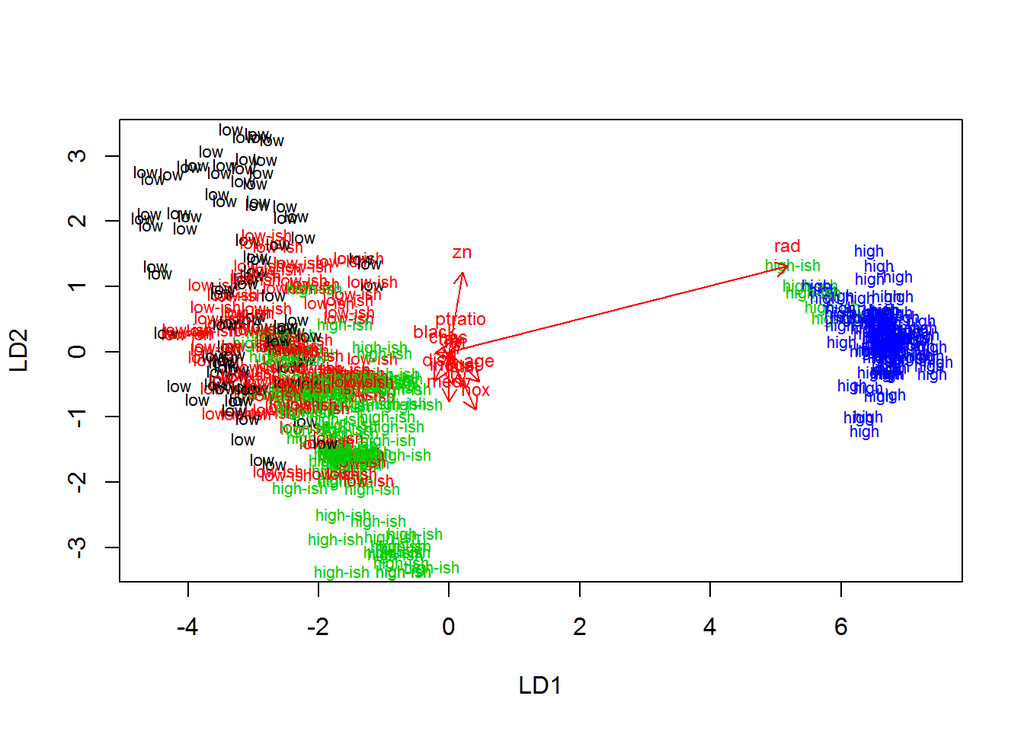

```r
lda.arrows <- function(x, myscale = 1, arrow_heads = 0.1, color = "red", tex = 0.75, choices = c(1,2)){
  heads <- coef(x)
  arrows(x0 = 0, y0 = 0,
         x1 = myscale * heads[,choices[1]],
         y1 = myscale * heads[,choices[2]], col=color, length = arrow_heads)
  text(myscale * heads[,choices], labels = row.names(heads),
       cex = tex, col=color, pos=3)
}
classes <- as.numeric(TrainingSet$crime.factor)
plot(lda.fit, dimen = 2, col=classes, pch=classes);lda.arrows(lda.fit, myscale = 1.5)
```

Frankly, I don’t get much out of this plot. It’s too messy and cluttered for me to fully wrap my head around.

Our next step is using the model for predictions. We’ll start by storing the actual crime categories of the testing set in a separate vector and then removing that column from the dataset, in order to make the prediction game more interesting:

```r
correct.classes<-TestingSet$crime.factor
TestingSet<-TestingSet[,which(colnames(TestingSet)!="crime.factor")]
```

Then we make predictions in a familiar way…

```r
lda.pred <- predict(lda.fit, newdata = TestingSet)
```

…followed by a cross-tabulation of the predicted and observed outcomes:

```r
table(real = correct.classes, predicted = lda.pred$class)
```

```
##           predicted
## real       low low-ish high-ish high
##   low       19      11        1    0
##   low-ish    5      14        5    0
##   high-ish   1      11       13    1
##   high       0       0        1   20
```

## K-Means Cluster Analysis

Cluster analysis is used to identify meaningful categories within a population. A meaningful category is a subgroup of the population whose members, in one way or another, behave similarly to other members of that same group, and dissimilarly from the members of the other subgroups.

As humans, we have a built-in pattern recognition firmware that helps us place the real-world phenomena that we encounter into pre-determined categories and respond to them accordingly. Therefore, the utility of cluster analysis might not be quite as intuitively obvious as that of a technique such as regression analysis or LDA. An example of a situation where cluster analysis may be useful is if, say, we discover a new species of deep-sea fish. At the beginning, we will have very little knowledge of the scale of variation – morphological or otherwise – present in the species. We might even have stumbled upon an entire new taxon of fish comprising more than one separate species! In cluster analysis, we would gather measurements on a set of characteristics from as large a sample of the population as possible – say, weight, length, number of scales, tooth length, etc. – and then use cluster analysis to see how many meaningful subgroups the population seems to divide into. After doing so, we might summon a board of biologists to decide whether these subgroups represent a set of sub-species of a single new species, or a set of more than one new species. Then we would proceed to give them names, descriptions, and so on.

In the present exercise, we will use cluster analysis to see how many meaningful group distinctions emerge among the different Massachusetts townships represented in our dataset. To do this, we need a version of the Boston dataset where *crim* is back in numeric format, and everything has been scaled:

```r
Boston.adulterated<-Boston #Back up the version in which crime is a factor.
Boston<-as.data.frame(scale(Boston.unscaled)) #Scale the original version of Boston and make sure the result is a data frame:
head(Boston)
```

```
##         crim         zn      indus       chas        nox        rm
## 1 -0.4193669  0.2845483 -1.2866362 -0.2723291 -0.1440749 0.4132629
## 2 -0.4169267 -0.4872402 -0.5927944 -0.2723291 -0.7395304 0.1940824
## 3 -0.4169290 -0.4872402 -0.5927944 -0.2723291 -0.7395304 1.2814456
## 4 -0.4163384 -0.4872402 -1.3055857 -0.2723291 -0.8344581 1.0152978
## 5 -0.4120741 -0.4872402 -1.3055857 -0.2723291 -0.8344581 1.2273620
## 6 -0.4166314 -0.4872402 -1.3055857 -0.2723291 -0.8344581 0.2068916
##          age      dis        rad        tax    ptratio     black
## 1 -0.1198948 0.140075 -0.9818712 -0.6659492 -1.4575580 0.4406159
## 2  0.3668034 0.556609 -0.8670245 -0.9863534 -0.3027945 0.4406159
## 3 -0.2655490 0.556609 -0.8670245 -0.9863534 -0.3027945 0.3960351
## 4 -0.8090878 1.076671 -0.7521778 -1.1050216  0.1129203 0.4157514
## 5 -0.5106743 1.076671 -0.7521778 -1.1050216  0.1129203 0.4406159
## 6 -0.3508100 1.076671 -0.7521778 -1.1050216  0.1129203 0.4101651
##        lstat       medv
## 1 -1.0744990  0.1595278
## 2 -0.4919525 -0.1014239
## 3 -1.2075324  1.3229375
## 4 -1.3601708  1.1815886
## 5 -1.0254866  1.4860323
## 6 -1.0422909  0.6705582
```

Then we calculate the Euclidean distance between each town:

```r
dist_eu<-dist(Boston)
```

Finally, we apply the clever algorithm shown in the Datacamp exercise in order to visually identify the optimal (most succinct and informative) number of of clusters (groups) into which the dataset divides:

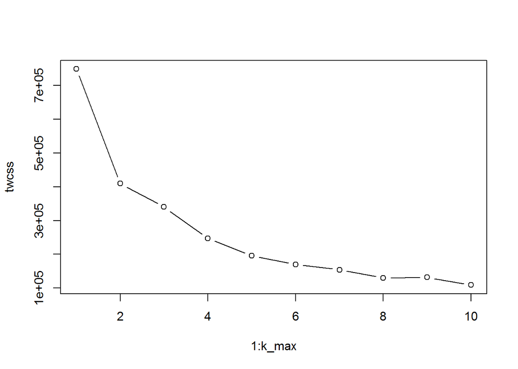

```r
k_max <- 10;twcss <- sapply(1:k_max, function(k){kmeans(dist_eu, k)$tot.withinss});plot(1:k_max, twcss, type='b')
```

Here we face the same dilemma as in stepwise regression: we can see that increasing the number of clusters decreases the number of residual variance, which is the goal. But more clusters means more categorizations, i.e., more complexity, more explaining to do, and more cognitive load. Therefore, we will abide by the rule of thumb – the optimal number of clusters is the one that brings about the most radical change in residual variance – and declare that 2 is the winning number. If we were seriously pursuing this line of investigation, we would now examine the clusters, identify their shared characteristics, and perhaps give them informative names or labels. But those are not the instructions. The instructions are to visualize the clusters. Hence now we visualize the clusters:

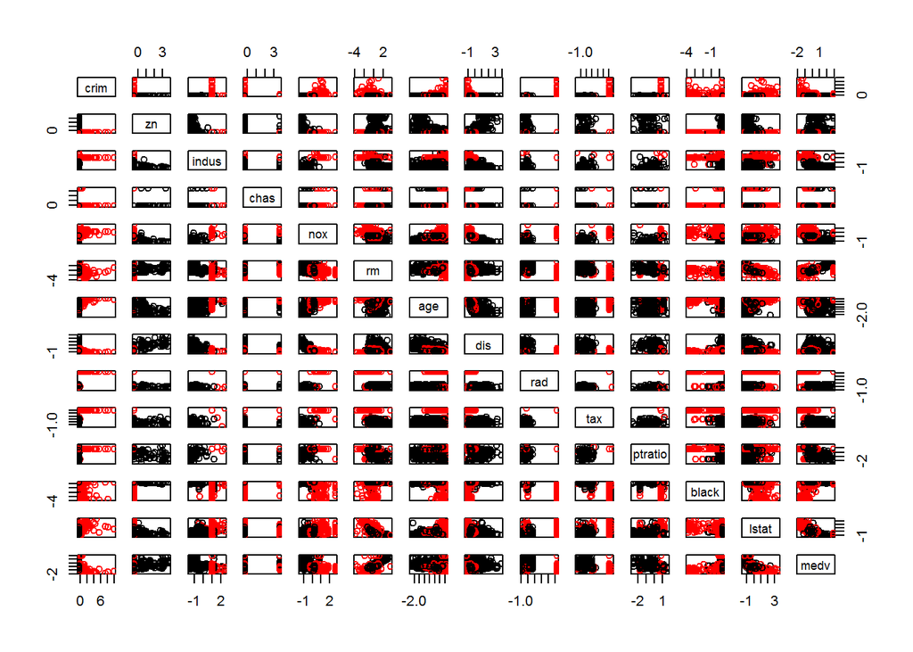

```r
km <-kmeans(dist_eu, centers = 2)
pairs(Boston, col = km$cluster)
```

I don’t get much out of this plot, either. There’s too much stuff jammed into a tight space.

## Bonus

We’ll now perform this analysis in reverse. We’ll take 4 clusters – this seems a relatively good number, judging from the second-to-last-plot – and perform LDA on *Boston* with the 4 clusters as target classes, in order to try and identify their common characteristics.

```r
km4<-kmeans(dist_eu, centers = 4)
Boston$cluster<-km4$cluster
(ld4.4c<-lda(cluster ~ ., data=Boston))
```

```
## Call:
## lda(cluster ~ ., data = Boston)
##
## Prior probabilities of groups:
##         1         2         3         4
## 0.2707510 0.2173913 0.1897233 0.3221344
##
## Group means:
##         crim          zn      indus        chas        nox          rm
## 1  0.9759730 -0.48724019  1.0836745  0.07252643  1.2746122 -0.51504943
## 2 -0.2781708 -0.48236779  0.4449338 -0.27232907  0.1112885 -0.34491541
## 3 -0.3904431  1.29327757 -0.8829277  0.67093453 -0.7094969  1.05013774
## 4 -0.4026194 -0.02663978 -0.6910740 -0.27232907 -0.7285393  0.04717328
##          age        dis        rad         tax    ptratio      black
## 1  0.8854486 -0.9186628  1.3368585  1.35643451  0.5296467 -0.8273642
## 2  0.4730244 -0.4156930 -0.2959232 -0.05777454  0.4757260  0.1720595
## 3 -0.6459300  0.7595211 -0.6074231 -0.64709824 -0.9518678  0.3430417
## 4 -0.6830053  0.6053314 -0.5661684 -0.71996870 -0.2055960  0.3772414
##        lstat       medv
## 1  0.9917971 -0.7561841
## 2  0.2721432 -0.3240236
## 3 -0.8065795  1.1616548
## 4 -0.5422106  0.1700672
##
## Coefficients of linear discriminants:
##                 LD1         LD2         LD3
## crim    -0.08347580  0.25229152  0.23494161
## zn      -0.50086410  1.07427556 -0.73572327
## indus   -0.19066361 -0.38532493 -0.51849315
## chas     0.05133571  0.66311801 -0.02000862
## nox     -1.48554172  0.53651016  0.37267367
## rm       0.20818955  0.40857906 -0.18625561
## age     -0.15978026  0.02494374 -0.66480469
## dis      0.22369038  0.20325447  0.52351112
## rad     -0.22891423 -0.12421387  1.52917037
## tax     -1.04859002  0.58543578 -0.69932224
## ptratio -0.45539412 -0.13690964 -0.60978717
## black    0.28206885 -0.13889043 -0.08150766
## lstat   -0.43261121  0.62600094 -0.27284565
## medv    -0.11825412  0.74838356 -0.33152714
##
## Proportion of trace:
##    LD1    LD2    LD3
## 0.8304 0.1374 0.0321
```

Judging from the coefficients of the Linear Discrimimants (LDs), it appears that air pollution is by far most significant discriminating variable between the clusters, followed by property tax rate. However, it is not entirely clear to me how these coefficients are to be interpreted and applied. There are always K-1 of them, where K is the number of classes/clusters. Is it the case that LD1 differentiates the first cluster from the second, while LD2 differentiates the second cluster from the third? Hmmm… if the treatment of factors in regression analysis is any indication, then it seems likelier that one of the classes/clusters is used as the reference cluster, and the Linear Discriminants differentiate the other clusters from this reference cluster. This would explain why Proportion of Trace (=explanatory power) is highest for LD1 and progressively much smaller for the other LDs – we already saw in the previous section that 2 is the optimal number of clusters, so the discriminant differentiating these two main clusters is by far the most significant one. Our current model has 4 clusters, and the drastically lower Proportion of Trace (explanatory power) of the other Linear Discriminants compared to the first one reflects the fact that adding new clusters after the first two yields diminishing returns. In other words, any additional classifications of the data that are done after the initial 2-way classification are much less helpful than the original 2-way classification. They do increase the overall predictive power, but it is debatable whether this improvement is enough to justify the resulting increase in model complexity.

However, what exactly do the coefficients represent? How are they calculated? In linear and logistic regression, we can manually predict the value of the response variable using the coefficients. Can we similarly use the linear discriminant coefficients to predict which cluster a given data point belongs to? If so, how exactly is this done? I have yet to find an answer to this, neither by Googling nor in any of the course materials.

Now it’s time to draw one of those goofy arrow plots again – biplot is what I think it’s called. Sigh. Do I really have to?

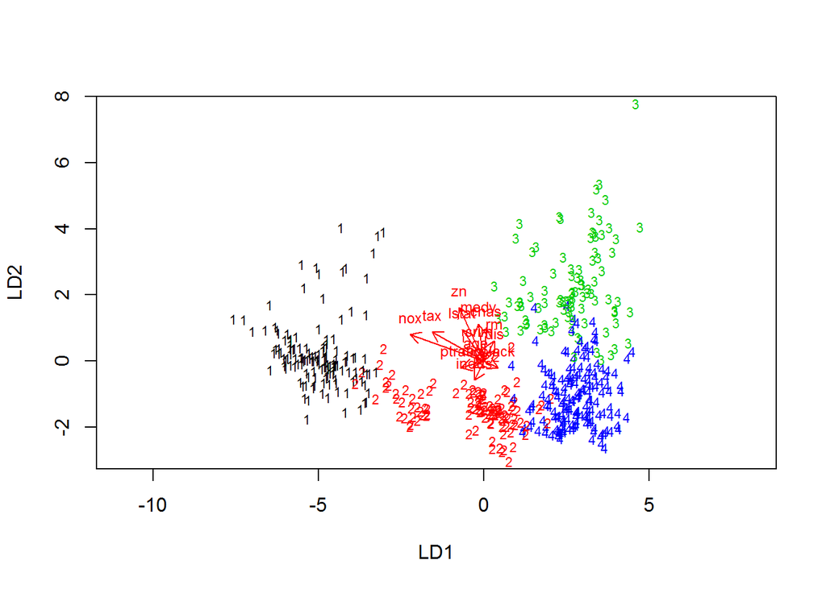

```r
luokat <- Boston$cluster
plot(ld4.4c, dimen = 2, col=luokat, pch=luokat);lda.arrows(ld4.4c, myscale = 1.5)
```

Try as I might, I just can’t extract a whole lot of useful information from this plot. Maybe I could if there were fewer variables and the picture didn’t get so cramped. But the instructions were what they were. Pretty much the only bits of data that I’m able to glean from this plot are these two:

1.Air pollution correlates with Cluster 1. Well that’s to be expected of the core regions of the city, where the bulk of cars and businesses are.

2.Property Tax rates also correlate with Cluster 1. This one is harder to decipher. I imagine it might be because being close to downtown is valued highly, especially by businesses, so those properties are also taxed more heavily regardless of their condition.

As the variables that are the most influential linear separators of the clusters, I can’t answer that confidently since I’m still unclear on how to interpret the Linear Determinant coefficients. But if the Group Means are any indicator (and they darn well should be), then I’d say the biggest differentiators are *tax*, *indus*, *rad* and *nox*. And I would also say that these variables likely reflect the the Downtown-Suburban dichotomy. This would also explain why the WCSS by Clusters plot earlier showed 2 to be the ideal number of clusters. It was probably showing us this same dichotomy that it was capturing, and our present 4-cluster model just adds a bit of extra nuance to it – at the cost of increased model complexity.